# Lab_assignment

2025-09-05

# 1) Load & preview the data

In this section, I load the dataset and check the number of rows, columns, and key variables. This helps confirm the data was read correctly.

```
## Rows: 60   Columns: 20
```

```
## Rows: 60
## Columns: 20
## $ context_provided               <chr> "(1) context\nProductive failure is to …
## $ prompt_used                    <chr> "Now I want you to generate math proble…
## $ id                             <dbl> 10520937941, 10715289739, 22180112528, …
## $ model                          <chr> "GPT-4o", "Phi-3", "GPT-4o", "GPT-4o", …
## $ themes                         <chr> "Sports", "Sports", "Sports", "Sports",…
## $ interests                      <chr> "Basketball, Stephen Curry", "Basketbal…
## $ grade                          <chr> "7th grade", "7th grade", "7th grade", …
## $ exact_standard                 <chr> "CCSS.Math.Content.7.RP.A.2", "CCSS.Mat…
## $ target_domain                  <chr> "Ratios & Proportional Relationships", …
## $ prior_knowledge                <chr> "Ratios & Proportional Relationships, T…
## $ prior_knowledge_exact_standard <chr> "CCSS.Math.Content.7.RP.A.1, CCSS.Math.…
## $ illustration                   <chr> "Stephen Curry presents a math challeng…
## $ title                          <chr> "Stephen Curry's Free Throw Challenge",…
## $ description                    <chr> "It was an exciting afternoon at the Go…
## $ apk                            <dbl> 2.5, 2.5, 2.5, 2.0, 3.0, 2.5, 2.5, 2.0,…
## $ ssc                            <dbl> 2.5, 2.0, 2.5, 1.0, 3.0, 2.0, 2.0, 2.5,…
## $ ae                             <dbl> 3.0, 2.5, 3.0, 1.5, 3.0, 2.0, 3.0, 1.5,…
## $ mr                             <dbl> 3.0, 2.0, 3.0, 2.5, 3.0, 2.0, 2.5, 2.0,…
## $ oe                             <dbl> 3.0, 2.0, 3.0, 3.0, 3.0, 2.0, 2.0, 2.0,…
## $ final_score                    <dbl> 14.0, 11.0, 14.0, 10.0, 15.0, 10.5, 12.…
```

# 2) Detect columns & tidy labels

Next, I identify the important columns we want to analyze. In particular, we need to know which column tells us the model that produced the problem (GPT or Phi3), and which column stores the overall quality score for the problem. I also clean up the labels so that the model names are consistent and easy to compare.

# 3) Per-metric analysis (Welch t + Hedges’ g)

I compare the two models on Final Score and on each sub-facet (APK, SSC, AE, MR, OE). For each comparison I do two things:

Statistical test (Welch’s t-test): checks if the difference in averages is likely to be real or just due to random variation.

Effect size (Hedges’ g): tells us how big the difference is in practical terms (small, medium, large).

These results show not just whether GPT and Phi3 differ, but also how much they differ.

# 4) Formatted table

I organized the results into a clear summary table. It shows, for each metric: the average score of GPT and Phi3, the size of the difference, the statistical test results, and the effect size with a confidence interval. We can easily compare the two models across all dimensions.

Summary statistics, Welch t-tests, Hedges’ g (FDR-adjusted p in p_adj)

| Metric | GPT M (SD) | Phi 3 M (SD) | t | p | p_adj | d | CI |
| --- | --- | --- | --- | --- | --- | --- | --- |
| Final Score | 13.38 (1.88) | 10.67 (2.73) | 4.490 | 4.04e-05 | 9.42e-05 | 1.144 | [0.599, 1.681] |
| ae | 2.75 (0.47) | 2.45 (0.71) | 1.929 | 5.94e-02 | 6.93e-02 | 0.492 | [-0.018, 0.997] |
| apk | 2.65 (0.35) | 2.42 (0.53) | 2.019 | 4.88e-02 | 6.83e-02 | 0.515 | [0.004, 1.021] |
| id | 481485622386.97 (316357856029.03) | 582600191210.10 (249170759041.81) | -1.375 | 1.75e-01 | 1.75e-01 | -0.350 | [-0.853, 0.155] |
| mr | 2.70 (0.43) | 1.83 (0.61) | 6.397 | 0.00e+00 | 3.00e-07 | 1.630 | [1.044, 2.206] |
| oe | 2.77 (0.47) | 1.88 (0.64) | 6.106 | 1.00e-07 | 4.00e-07 | 1.556 | [0.977, 2.125] |
| ssc | 2.52 (0.55) | 2.08 (0.62) | 2.874 | 5.69e-03 | 9.95e-03 | 0.732 | [0.212, 1.246] |

# 5) Visuals

Numbers are important, but visuals help us see patterns more easily. I use three types of plots to visualize the results:

5.1 Final Score plot: compares overall quality between GPT and Phi3.

5.2 Sub-facet plots: show differences on each individual facet (APK, SSC, AE, MR, OE).

5.3 Effect size plot (forest plot): shows how big the differences are, with lines for uncertainty (confidence intervals).

These visuals let us see not only whether GPT scores higher, but also how consistent and meaningful the differences are. ## 5.1 Final Score by Model

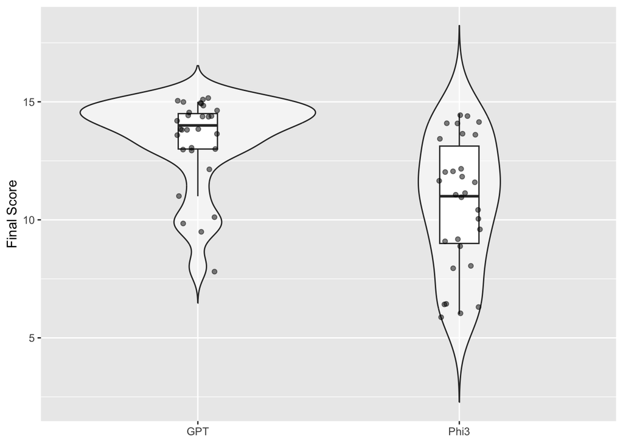

Final Score by Model

## 5.2 Sub-facet scores by Model

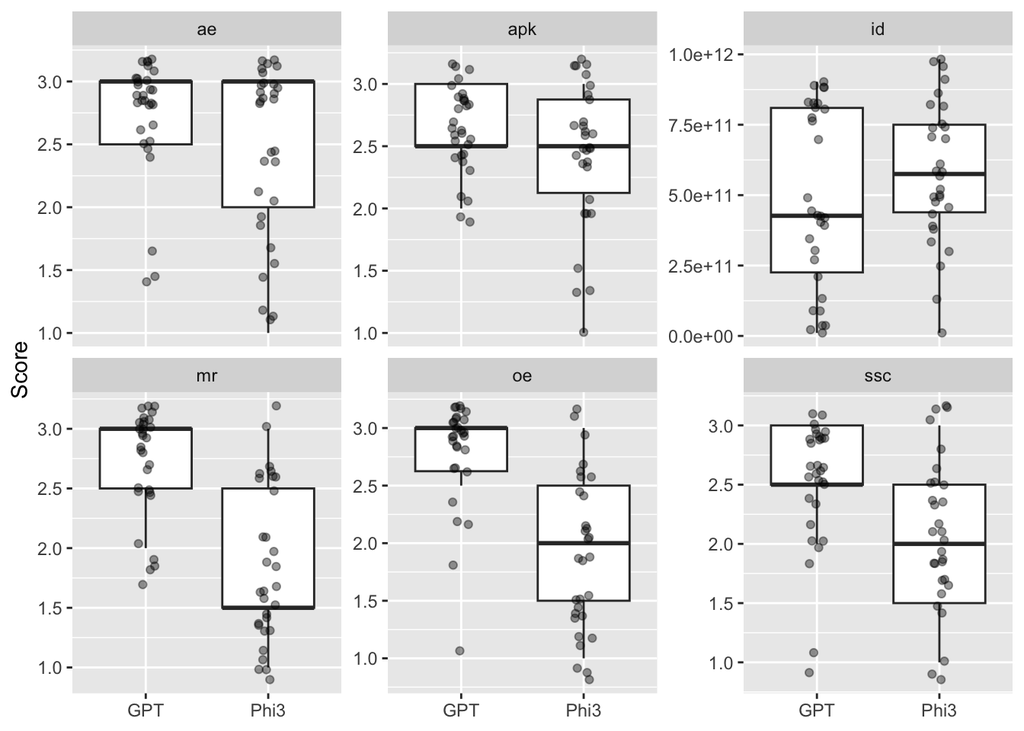

Sub-facet scores by Model

## 5.3 Effect sizes (Hedges’ g, GPT − Phi3)

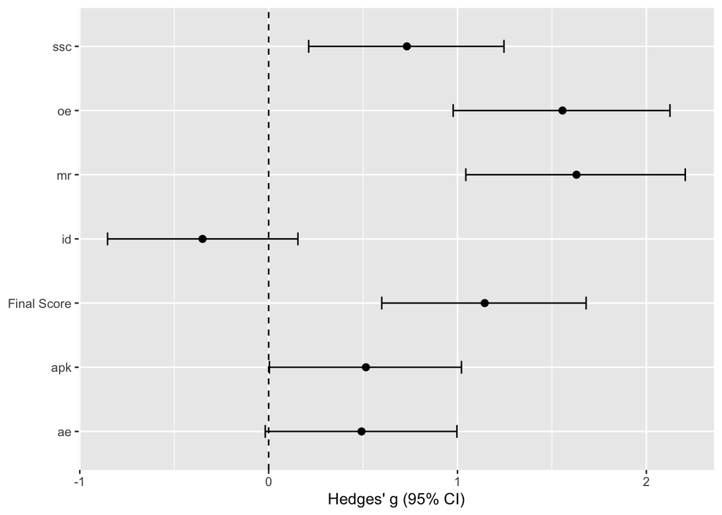

Effect sizes (Hedges’ g, GPT − Phi3)